# Analyzing Youth Voter Turnout Through the Lens of Descriptive Representation

#### Candidate Data

```r
candidates <- read.csv("candidate_data/nys_candidates_ages.csv")

# candidates$election_districts <-gsub("\\{|\\}", "",candidates$election_districts)

#' Return the last element in a list
#'
#' This function will be used to return the last
#' district that a candidate ran in, which
#' should be the district they ran in during 2014.
get_last <- function(array) {
  # Array is a list
  return( as.integer( array[length(array)] ) )
}

# For 2010, assume the second to last district (if more than one) --> district at last census usually, if there was a change
get_secondlast <- function(array) {
  # Array is a list
  filtered <- unique(array)
  if (length(filtered == 1)) {
    return( as.integer(filtered[1]) )
  }
  else {
    return( as.integer(array[length(filtered) - 1]) )
  }
}

# Recode candidate status
candidates <- candidates %>%
  mutate(sta10 = recode(sta10, C = 1, O = 2, I = 3, .default = 0),
           sta14 = recode(sta14, C = 1, O = 2, I = 3, .default = 0))

# Filter only candidates who ran in 2014 and did not run unopposed
candidates.14 <- candidates %>%
  filter(gen14 == 1)

# For 2014, assume the last district
election.districts <- strsplit(as.character(candidates.14$election_districts), ",")
candidates.14$district <- sapply(lapply(election.districts, function(x) get_last(x)), function(x) return(x[1]))

# Get candidate age for 2014 midterm
candidates.14$age <- as.period(interval(as.Date(candidates.14$dob, format = "%m/%d/%Y"), "2014-11-4"), units = "year")$year

# For each district, get the youngest age and the average age
districts.14 <- candidates.14 %>%
  group_by(district) %>%
  summarise(youngest_age = min(age, na.rm = T),
            average_age = mean(age, na.rm = T),
            status = max(sta14))
warning("\nNo age data for district 4 in 2014, filtering out.")
districts.14 <- districts.14 %>%
  filter(district != 4) %>%
  filter(!is.na(district))

# Do the same thing for 2010
# Filter only candidates who ran in 2010 and did not run unopposed
candidates.10 <- candidates %>%
  filter(gen10 == 1)

# For 2010, assume the second to last district (if more than one) --> district at last census usually, if there was a change
election.districts <- strsplit(as.character(candidates.10$election_districts), ",")
candidates.10$district <- sapply(sapply(election.districts, function(x) get_secondlast(x)), function(x) return(x[1]))
# Get candidate age for 2014 midterm
candidates.10$age <- as.period(interval(as.Date(candidates.10$dob, format = "%m/%d/%Y"), "2010-11-2"), units = "year")$year

# For each district, get the youngest age and the average age
districts.10 <- candidates.10 %>%
  group_by(district) %>%
  summarise(youngest_age = min(age, na.rm = T),
            average_age = mean(age, na.rm = T),
            status = max(sta10))
# Filter out NA
districts.10 <- districts.10 %>%
  filter(!is.na(district))
```

#### Master Dataframe

Create one dataframe to link all of the district-level data together

```r
all14 <- turnout14 %>%
  inner_join(districts.14, by = c("CD" = "district"))

all10 <- turnout10 %>%
  inner_join(districts.10, by = c("CD" = "district"))

master <- rbind(all10, all14) %>% arrange(CD, year)
```

```r
master$age_cat <- "older" # init as older
master$age_cat[master$youngest_age <= 30] <- "young"
master$age_cat <- factor(master$age_cat, levels = c("older", "young"))
master$year <- factor(master$year, levels = c(2010, 2014))
master$CD <- as.factor(master$CD)

master <- master %>%
  mutate(inc_status = factor(case_when(status == 1 ~ "open",
                                TRUE ~ "incumbent")))
```

## Analysis

### One-Way Comparisons

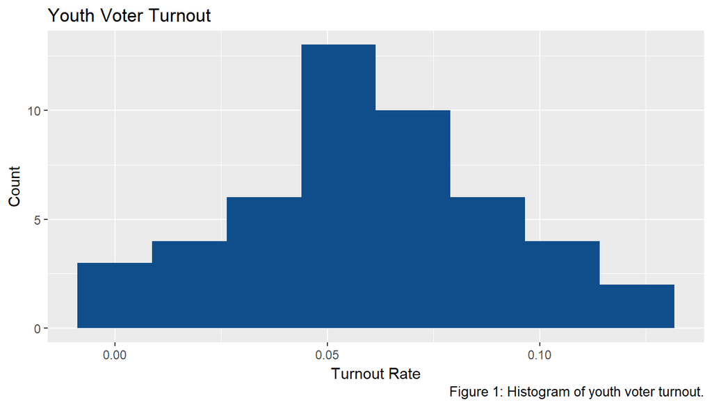

```r
fig.num <- 0
my_pal <- c("#FF6347" ,"#104E8B") # define my color palette

# Plot histogram of youth turnout
fig.num <- fig.num + 1
youth_turnout <- ggplot(master) + geom_histogram(aes(x = turnout_rate), bins = 8,
                                                 fill = my_pal[2]) +
  labs(title = "Youth Voter Turnout", x = "Turnout Rate", y = "Count",
       caption = paste("Figure ", fig.num, ": Histogram of youth voter turnout.", sep = ""))
youth_turnout
```

### Two-Way Comparison

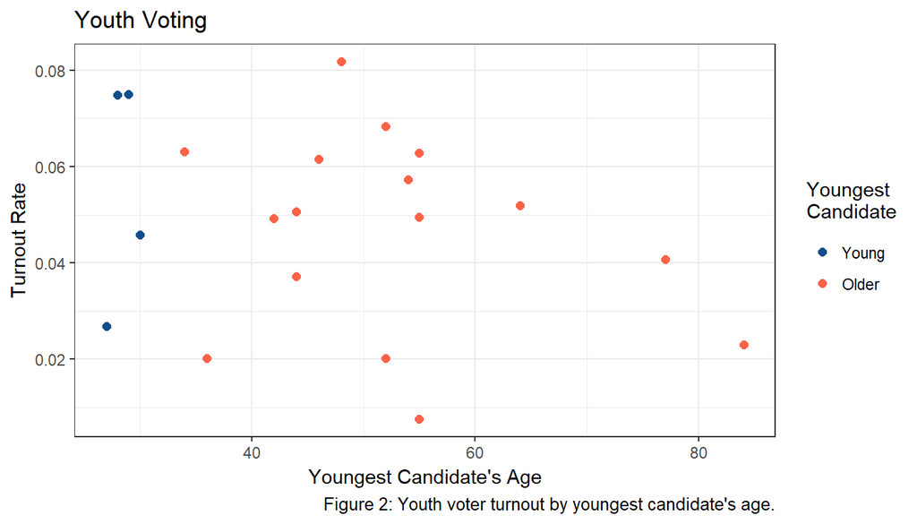

```r
# Plot turnout by age, split plots by year, and color by age category
# First, do continous.

fig.num <- fig.num + 1
compare_plot <- ggplot(master %>% filter(year == 2014)) +
  geom_point(aes(x = youngest_age, y = turnout_rate, col = age_cat), size = 2) +
  labs(title = "Youth Voting", x = "Youngest Candidate's Age", y = "Turnout Rate",
       caption = paste("Figure ", fig.num, ": Youth voter turnout by youngest candidate's age.", sep = "")) +
  scale_color_manual(values = my_pal, name = "Youngest \nCandidate",labels = c("Older", "Young"), guide = guide_legend(reverse=TRUE)) +
  theme_bw()
compare_plot
```

```r
# fig.num <- fig.num + 1
# inc_plot <- ggplot(master) + geom_point(aes(x = youngest_age, y = turnout_rate, col = inc_status), size = 2) +
#   facet_grid(. ~ year) +
#   labs(title = "Youth Voting", x = "Youngest Candidate's Age", y = "Turnout Rate",
#        caption = paste("Figure ", fig.num, ": Youth voter turnout by youngest candidate's age and seat status.", sep = "")) +
#   scale_color_manual(values = my_pal, name = "Candidate \nStatus",labels = c("Incumbent", "Open"), guide = guide_legend(reverse=TRUE)) +
#   theme_bw()
# inc_plot

# It doesn't make sense to inculde an incumbency effect since only two seats a year
# were open.
```

```r
master %>%
  group_by(age_cat, year) %>%
  summarise(avg = mean(turnout_rate), count = n()) %>%
  arrange(year) # %>% xtable::xtable()
```

```
## # A tibble: 4 x 4
## # Groups:   age_cat [2]
##   age_cat year     avg count
##   <fct>   <fct>  <dbl> <int>
## 1 older   2010  0.0714    26
## 2 young   2010  0.0205     2
## 3 older   2014  0.0466    16
## 4 young   2014  0.0556     4
```

I am not trying to prove the the older a candidate gets, the lower the youth turnout rate. My hypothesis is that younger candidates (on a absolute scale) raise turnout relative to other candidates. Therefore, the categorical age variable is the correct measure.

### Logistic Regression

I am going to start with a logistic regression model predicting percentage of young people who vote in a district.

```r
logit <- glm(data = master %>% filter(year == 2014), cbind(turnout, young_population - turnout) ~  inc_status + age_cat , family = "binomial")
summary(logit)
```

```
##
## Call:
## glm(formula = cbind(turnout, young_population - turnout) ~ inc_status +
##     age_cat, family = "binomial", data = master %>% filter(year ==
##     2014))
##
## Deviance Residuals:
##     Min       1Q   Median       3Q      Max
## -62.452  -14.741    4.317   18.402   43.796
##
## Coefficients:
##                 Estimate Std. Error z value Pr(>|z|)
## (Intercept)    -3.063431   0.004512 -678.98   <2e-16 ***
## inc_statusopen  0.394117   0.012027   32.77   <2e-16 ***
## age_catyoung    0.126137   0.009694   13.01   <2e-16 ***
## ---
## Signif. codes:  0 '***' 0.001 '**' 0.01 '*' 0.05 '.' 0.1 ' ' 1
##
## (Dispersion parameter for binomial family taken to be 1)
##
##     Null deviance: 14995  on 19  degrees of freedom
## Residual deviance: 13527  on 17  degrees of freedom
## AIC: 13730
##
## Number of Fisher Scoring iterations: 4
```

```r
# Random effect for year
# library(lme4)
# logit.mixed <- glmer(data = master, cbind(turnout, young_population - turnout) ~ (1 | year) + inc_status + age_cat, family = "binomial")
# summary(logit.mixed)

# Random effect for Congressional District -- makes no sense since CD boundaries change
# Random effect for some geographic boundary might be a good idea
# logit.mixed2 <- glmer(data = master, cbind(turnout, young_population - turnout) ~ (1 | year) + (1 | CD) + age_cat, family = "binomial")
# summary(logit.mixed2)
```

### Visualize Model

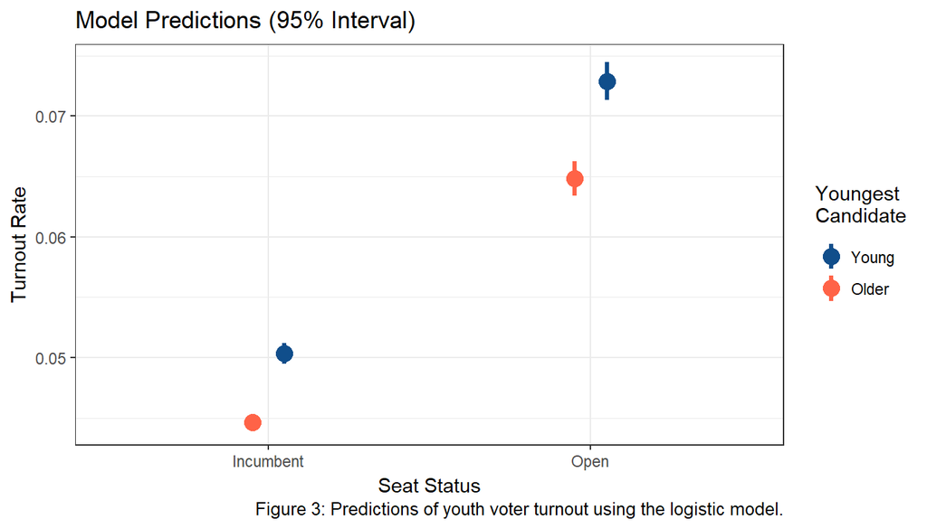

```r
ages <- as.factor(c("young","older"))
stati <- as.factor(c("incumbent", "open"))
X <- expand.grid(data.frame(age_cat = ages, inc_status = stati))
preds <- predict.glm(logit, newdata = X,  type = "link", se.fit = T)
everything <- cbind(X, preds$fit, preds$se.fit)
names(everything) <- c("age_cat", "inc_status", "fit", "se")
# Make 95% CI
everything <- everything %>%
  mutate(lower = fit -  se * qnorm(.975),
         upper = fit + se * qnorm(.975)) %>%
  # Now change log odds to probabilities
  mutate(lower = exp(lower) / (1 + exp(lower)),
         fit = exp(fit) / (1 + exp(fit)),
         upper = exp(upper) / (1 + exp(upper)))

fig.num <- fig.num + 1
pred_plot <- ggplot(everything, aes(x = as.factor(inc_status))) +
  geom_linerange(aes(ymin = lower, ymax = upper, col = age_cat), size =1.21, position = position_dodge(.2)) +
  geom_point(aes(y = fit, col = age_cat),
                  position = position_dodge(.2), size = 4) +
  labs(title = "Model Predictions (95% Interval)", x = "Seat Status", y = "Turnout Rate",
        caption = paste("Figure ", fig.num, ": Predictions of youth voter turnout using the logistic model.", sep = "")) +
  scale_color_manual(values = my_pal, name = "Youngest \nCandidate",labels = c("Older", "Young"), guide = guide_legend(reverse=TRUE)) +
  scale_x_discrete(labels = c("Incumbent", "Open")) +
  theme_bw()
pred_plot
```

#### Make Presentation

```r
library(officer)
library(magrittr) # `magrittr` supposedly makes officer usage easier

# Make slides with images
slides <- read_pptx() %>%
  # Compare turnout by candidate age
  add_slide(layout = "Title and Content", master = "Office Theme") %>%
  ph_with_gg(youth_turnout) %>%
  add_slide(layout = "Title and Content", master = "Office Theme") %>%
  ph_with_gg(compare_plot) %>%
  add_slide(layout = "Title and Content", master = "Office Theme") %>%
  ph_with_gg(pred_plot)
print(slides, target = "images.pptx")
```

#### Output Table

```r
stargazer(logit, out = "logit.html", type = "html",
          title = "Logistic Regression",
          covariate.labels = c("Intercept", "Open Seat", "Young Candidate"),
          dep.var.caption = "Youth Voter Turnout Rate",
          dep.var.labels.include = F,
          ci = T, intercept.bottom = FALSE,
           omit.stat = c("aic", "bic", "LL"))
```

### Nominial Age Categories

Run the analysis again, but this time break age into three different categories.

```r
master <- master %>%
  mutate(age_cat3 = case_when(
    youngest_age <= 30 ~ "Young",
    youngest_age <= 50 ~ "Mid-Aged",
    youngest_age <= 100 ~ "Old"
  ))
logit.3 <- glm(data = master %>% filter(year == 2014), cbind(turnout, young_population - turnout) ~  inc_status + age_cat3, family = "binomial")

summary(logit.3)
```

```
##
## Call:
## glm(formula = cbind(turnout, young_population - turnout) ~ inc_status +
##     age_cat3, family = "binomial", data = master %>% filter(year ==
##     2014))
##
## Deviance Residuals:
##     Min       1Q   Median       3Q      Max
## -55.791  -19.798    0.276   15.254   33.939
##
## Coefficients:
##                 Estimate Std. Error  z value Pr(>|z|)
## (Intercept)    -2.907822   0.006290 -462.290  < 2e-16 ***
## inc_statusopen  0.473975   0.012381   38.282  < 2e-16 ***
## age_cat3Old    -0.299183   0.009011  -33.201  < 2e-16 ***
## age_cat3Young  -0.054293   0.011065   -4.907 9.27e-07 ***
## ---
## Signif. codes:  0 '***' 0.001 '**' 0.01 '*' 0.05 '.' 0.1 ' ' 1
##
## (Dispersion parameter for binomial family taken to be 1)
##
##     Null deviance: 14995  on 19  degrees of freedom
## Residual deviance: 12427  on 16  degrees of freedom
## AIC: 12631
##
## Number of Fisher Scoring iterations: 4
```

```r
# stargazer(logit.3, out = "logit_3.html", type = "html",
#           title = "Logistic Regression with Three Levels",
#           covariate.labels = c("Intercept", "Open Seat", "Young Candidate", "Old Candidate"),
#           dep.var.caption = "Youth Voter Turnout Rate",
#           dep.var.labels.include = F,
#           ci = T, intercept.bottom = FALSE,
#            omit.stat = c("aic", "bic", "LL"))
```